# Predicción de prestamos

Roberto Caride

**Planteamiento del problema:**

La Compañía Dream Housing Finance se ocupa de la concesión de préstamos hipotecarios.  
Tienen presencia en todas las zonas urbanas, semiurbanas y rurales.

El cliente primero solicita un préstamo hipotecario y luego la compañía tiene que validar la idoneidad del cliente para el préstamo.

**Problema:**

La compañía desea automatizar el proceso de aprobación del préstamo en función de los detalles del cliente proporcionados al completar el formulario de solicitud en línea.

Estos detalles son género, estado civil, educación, número de dependientes, ingresos, monto del préstamo, historial de crédito y otros.

## Esquema a seguir:

1 - Desarrollo de hipótesis  
2 - Exploración de datos  
3 - Limpieza de datos  
4 - Ingeniería de características  
5 - Creación de modelo

## 1 - Desarrollo de hipótesis:

Se expondrán hipótesis iniciales que se consideren que pueden aportar valor al análisis.  
Estas hipótesis es posible que no se puedan resolver por falta de datos.

**Hipótesis:**

- Existe un sesgo a la hora de conceder un credito en función del genero.
- Existe un sesgo a la hora de conceder un credito en función del Estado civil
- Existe un sesgo a la hora de conceder un credito en función del número de personas dependientes
- Existe un sesgo a la hora de conceder un credito en función de la educación
- Existe un sesgo a la hora de conceder un credito en función de si la persona es autoempleado
- Es importante tener un historial crediticio positivo

## 2 - Exploración de datos

carga de librerías

| Variable | Descripción |
| --- | --- |
| Loan_ID | ID de préstamo único |
| Gender | Masculino femenino |
| Married | Solicitante casado (S / N) |
| Dependents | Número de dependientes |
| Education | Educación del solicitante (Graduado / No Graduado) |
| Self_Employed | Trabajador por cuenta propia (S / N) |
| ApplicantIncome | Ingreso del solicitante |
| CoapplicantIncome | Ingreso de coaplicantes |
| LoanAmount | Cantidad del préstamo en miles |
| Loan_Amount_Term | Plazo de préstamo en meses |
| Credit_History | Historial de crédito cumple con las directrices |
| Property_Area | Urbano / Semiurbano / Rural |
| Loan_Status | Préstamo aprobado (S / N) |

Nos aportan datos de entrenamiento y de test.

```r
df_train <- read.csv('./data/train_u6lujuX_CVtuZ9i.txt', na.strings = "")
df_test <- read.csv('./data/test_Y3wMUE5_7gLdaTN.txt', na.strings = "")
submission <- read.csv('./data/sample_submission_S7jWYrJ.csv', na.strings = "") #formato de envío para competición
```

Explorar valores nulos.

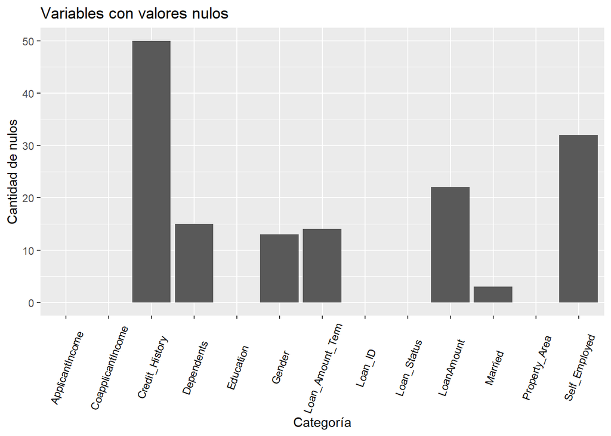

```r
nulos<- data.frame(sapply(df_train, function(x) sum(is.na(x))))
names(nulos) <- "valores_nulos"
nulos$variable <- rownames(nulos)

ggplot(nulos, aes(variable, valores_nulos)) +
  geom_col() +
  theme(axis.text.x = element_text(angle = 70, vjust = 0.5, color = "black")) +
  xlab("Categoría") +
  ylab("Cantidad de nulos") +
  ggtitle("Variables con valores nulos")
```

Apreciamos que tenemos valores nulos en “Credit_History”, “Dependents”, “Gender”, “Loan_Amount_Term”, “LoanAmount”, “Married”, “Self_Employed”

Veamos la distribución de los valores perdidos.

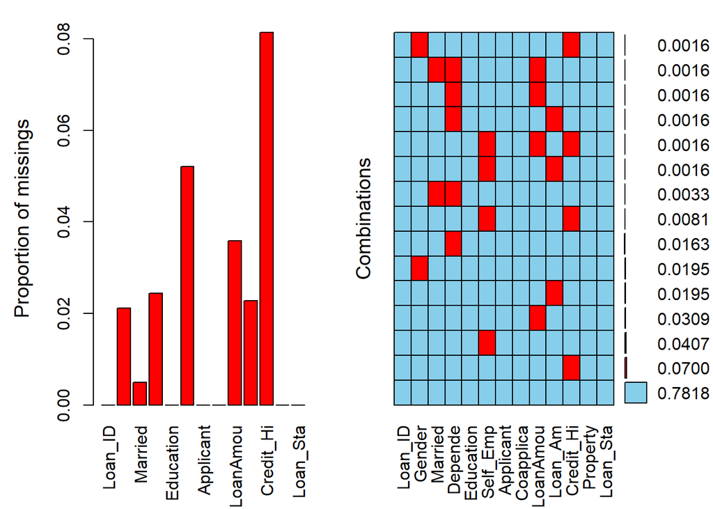

```r
vector <- as.data.frame(names(df_train))
aggr(df_train, prop = T, numbers = T, labels = c("Loan_ID", "Gender","Married", "Depende", "Education", "Self_Emp", "Applicant", "Coapplica", "LoanAmou", "Loan_Am", "Credit_Hi", "Property", "Loan_Sta"))
```

Parece que los valores faltantes muestran aleatoriedad, no parece que tengamos una variable que esté condicionando a otras, parece una estructura MCAR.

A destacar la cantidad de valores faltantes en “Credit_History”.

Vamos a explorar si existe relación entre distintas variables y la concesión de prestamos.

Evaluamos si el género es una variable dependiente de la concesión del préstamo.

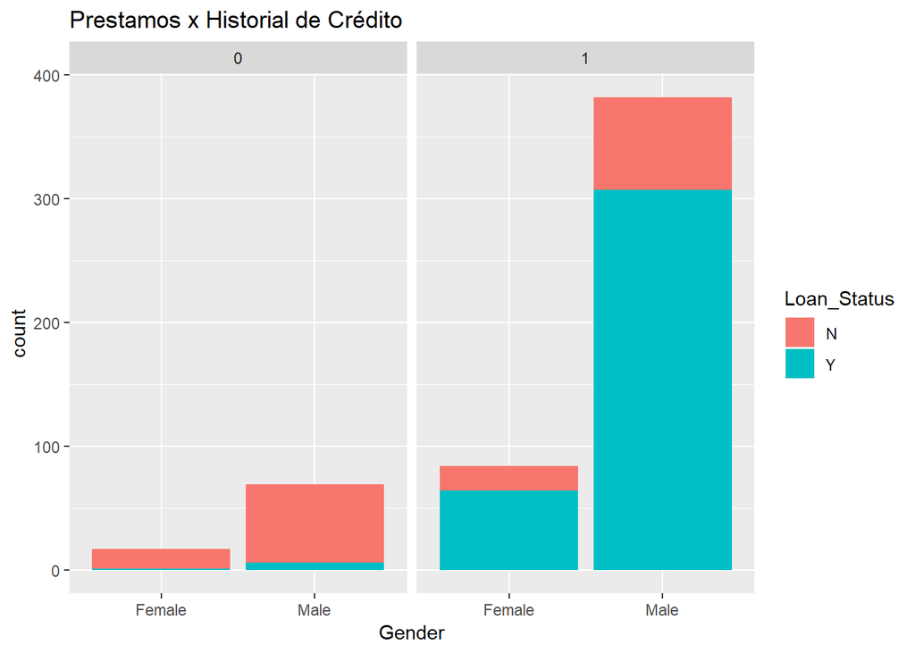

```r
ggplot(data = df_train[!is.na(df_train$Gender) & !is.na(df_train$Credit_History),]) +
  geom_bar(mapping = aes(x = Gender, fill = Loan_Status)) +
  labs(title = "Prestamos x Historial de Crédito") +
  facet_wrap(~Credit_History, nrow = 1)
```

No parece estar influyendo, no se aprecia un sesgo entre la concesión del préstamo y el género.

Se puede ver que hay un número menor de mujeres que solicitan el préstamo.

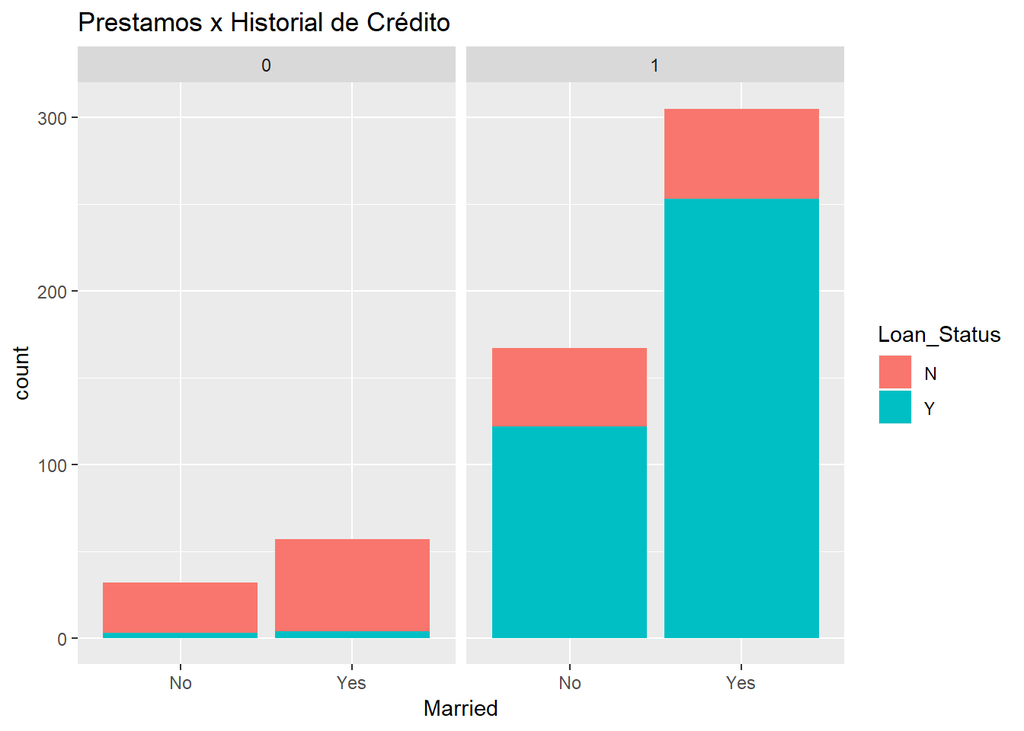

```r
ggplot(data = df_train[!is.na(df_train$Married) & !is.na(df_train$Credit_History),]) +
  geom_bar(mapping = aes(x = Married, fill = Loan_Status)) +
  labs(title = "Prestamos x Historial de Crédito") +
  facet_wrap(~Credit_History, nrow = 1)
```

Mayoritáriamente el solicitante está casado pero esto no influye en la adjuciación del préstamo.

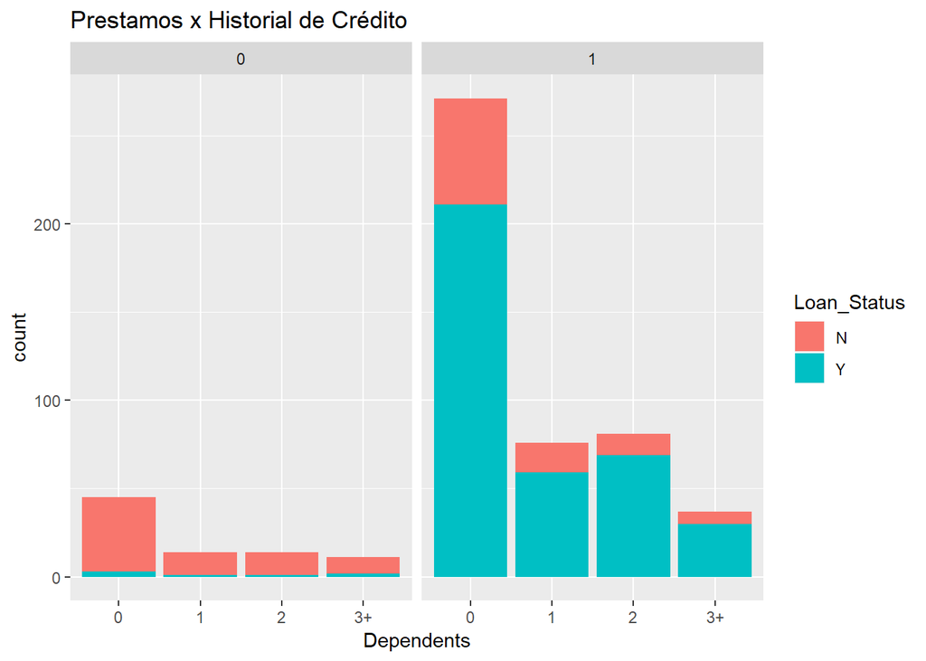

```r
ggplot(data = df_train[!is.na(df_train$Dependents) & !is.na(df_train$Credit_History),]) +
  geom_bar(mapping = aes(x = Dependents, fill = Loan_Status)) +
  labs(title = "Prestamos x Historial de Crédito") +
  facet_wrap(~Credit_History, nrow = 1)
```

Las personas con menor número de dependientes presentan la mayor cantidad de solicitudes pero este factor no parece que afecte a la solicitud.

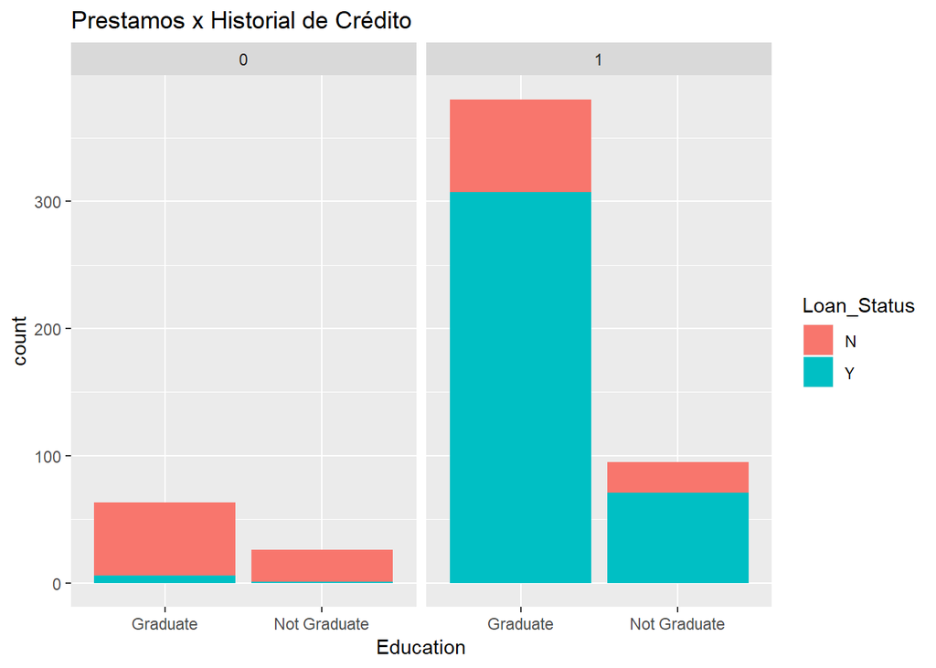

```r
ggplot(data = df_train[!is.na(df_train$Education) & !is.na(df_train$Credit_History),]) +
  geom_bar(mapping = aes(x = Education, fill = Loan_Status)) +
  labs(title = "Prestamos x Historial de Crédito") +
  facet_wrap(~Credit_History, nrow = 1)
```

Los graduados solicitan más creditos que los no graduados pero como en los casos anteriores no afecta a la concesión del mismo.

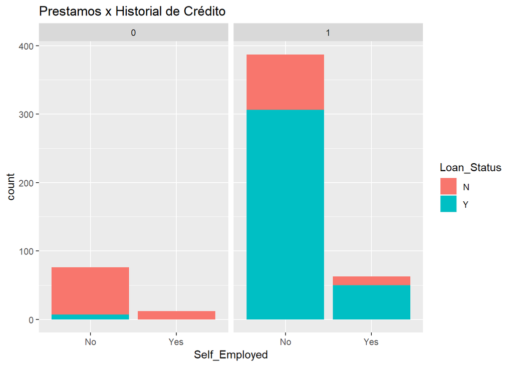

```r
ggplot(data = df_train[!is.na(df_train$Self_Employed) & !is.na(df_train$Credit_History),]) +
  geom_bar(mapping = aes(x = Self_Employed, fill = Loan_Status)) +
  labs(title = "Prestamos x Historial de Crédito") +
  facet_wrap(~Credit_History, nrow = 1)
```

Ser autoempleado no afecta a la concesión del credito pero mayoritáriamente lo solicitan los trabajadores por cuenta ajena.

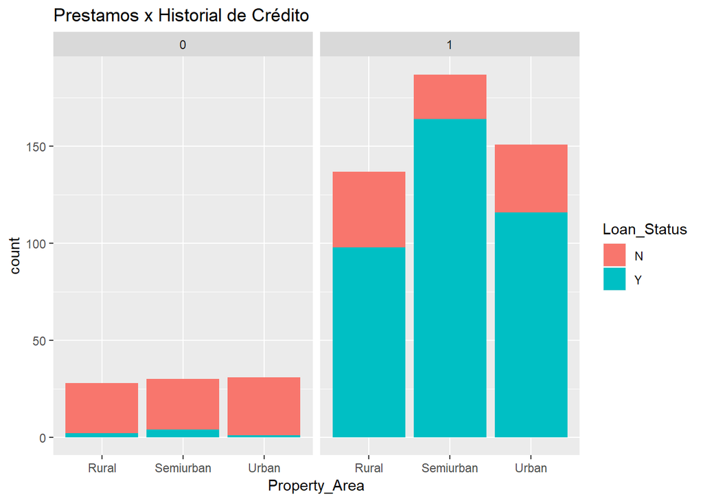

```r
ggplot(data = df_train[!is.na(df_train$Property_Area) & !is.na(df_train$Credit_History),]) +
  geom_bar(mapping = aes(x = Property_Area, fill = Loan_Status)) +
  labs(title = "Prestamos x Historial de Crédito") +
  facet_wrap(~Credit_History, nrow = 1)
```

La solicitud desde distintas áreas no afecta a la adjudicación del préstamo.

## 3 - Limpieza de los datos

### Imputación de variables

Se efectua la imputación de variables sobre “df_train” y “df_test”, posteriormente se vuelven a dividir los conjuntos de datos.

```r
df_test$Loan_Status <- "sin determinar"

df_temp <- rbind(df_train,df_test)

df_temp <- mice(df_temp[,2:13], printFlag = FALSE)
df_temp <- mice::complete(df_temp)

df_train <- cbind(df_train[1:614,1], df_temp[1:614,1:12])
df_test <- cbind(df_test[615:981,1], df_temp[615:981,1:11])
```

## 4- Ingeniería de características:

### Crear la variable “Total_Income”

Es fácil pensar que la empresa ha de tener en cuenta los ingresos del aplicante y del coaplicante por lo que crearemos una variables “Total_Income” que refleje el poder adquisitivo conjunto.

```r
df_train <- mutate(df_train, Total_Income = ApplicantIncome + CoapplicantIncome)
df_test <- mutate(df_test, Total_Income = ApplicantIncome + CoapplicantIncome)
```

### Crear la variable “Risk_Factor”

El riesgo en la concesión de un credito es muy relativo pues no sólo es importante la cantidad pedida o el plazo de devolución sino que también que capacidad de devolución tiene el solicitante o solicitantes, para ello se crea la variable “Risk_Factor” donde se trata de reflejar el riesgo de esa operación donde un valor alto mostrará una mayor dificultad de devolución del préstamo.

```r
df_train <- mutate(df_train, Risk_Factor = LoanAmount * 1000 /Loan_Amount_Term   / Total_Income)
df_test <- mutate(df_test, Risk_Factor = LoanAmount * 1000 /Loan_Amount_Term   / Total_Income)

df_train <- select(df_train, 1:12,"Total_Income", "Risk_Factor", "Loan_Status")
```

A continuación se muestra un gráfico con el “Total_Income” en función del “Risk_Factor”

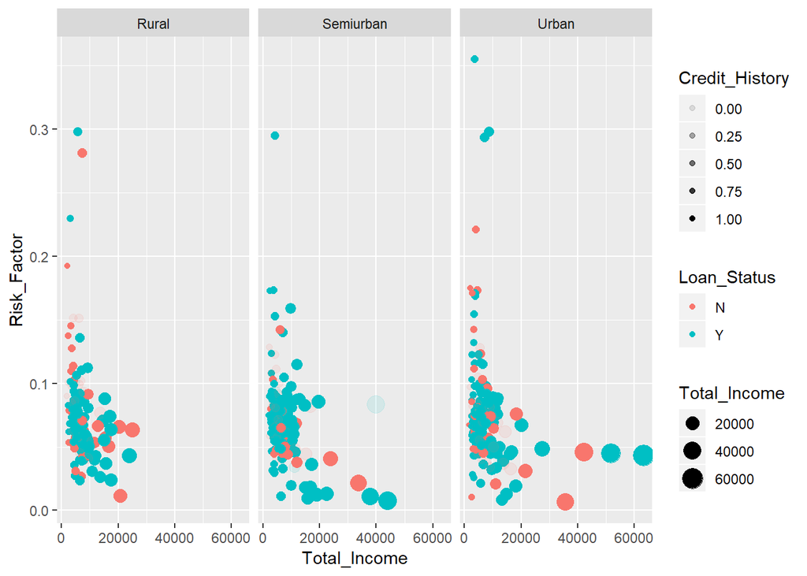

```r
muestra <- filter(df_train, Risk_Factor < 0.4, Total_Income < 70000)

ggplot(data = muestra) +
  geom_point(mapping = aes(x =Total_Income , y = Risk_Factor, color = Loan_Status, size = Total_Income, alpha = Credit_History)) +
  facet_wrap(~Property_Area, nrow = 1)
```

Se puede apreciar que la zona Rural es la que recibe menor número de peticiones y sus solicitantes parecen tener poca dispersión en cuanto a los ingresos y el factor de riesgo.

Semiurban y Urban presentan mayor dispersión de los datos.

Me llama la atención que algunos de los clientes con mayores ingresos, entre 20.000 y 40.000, un factor de riesgo bajo y con un historial crediticio favorable no le han concedido el préstamo.

## 5 - Creación de modelo

Ahora se prepara los datos para entrenar un modelo.  
Se opta por XGBoost.

### Crear matriz de datos

Creando una matriz y luego convirtiéndola al formato xgb.DMatrix propio de XGBoost (se incluye variable dependiente)

```r
#Variable dependiente
y_train <- as.data.frame(ifelse(df_train$Loan_Status == "Y", 1, 0))

#crear matriz sin la variable dependiente, así podemos controlar la creación de la misma
x1 <- data.matrix(df_train[,-c(1,15)]) #variables independientes
y_x1 <- data.matrix(y_train) #variable dependiente

x2 <- data.matrix(df_test[,-c(1)]) #variables independientes de test

dtrain_label <- xgb.DMatrix(x1, label = y_x1) #unir variables dependendiente e independiente en objeto xgb.DMatrix
```

### Crear rejilla, CV y modelo.

Se ha creado una rejilla de parámetros.

Se efectuan 100 iteraciones donde se alimenta con la rejilla de parámetros a un CV a la vez que se van almacenando los mejores parámetros.

Se incluye una semilla aleatoria en cada bucle.

Después se realiza la predicción de “df_test” para el modelo entrenado.

Por último se preparan los datos para el envío.

```r
best_param = list()
best_seednumber = 1234
best_logloss = Inf
best_logloss_index = 0

for (iter in 1:100) {
    param <- list(objective = "multi:softmax",
          eval_metric = "mlogloss",
          num_class = 2,
          max_depth = sample(4:10, 1), #default 6
          eta = runif(1, .01, .3), #default .3, rango 0,1
          gamma = runif(1, 0.0, 0.2), #default 0, rango 0,inf
          subsample = runif(1, .6, .9), #default 1, rango 0,1
          colsample_bytree = runif(1, .5, .8),  #default 1, rango 0,1
          min_child_weight = sample(1:40, 1), #default 1, rango 0,inf
          max_delta_step = sample(1:10, 1)
          )
    cv.nround = 1000
    cv.nfold = 5
    seed.number = sample.int(10000, 1)[[1]]
    set.seed(seed.number)
    mdcv <- xgb.cv(data=dtrain_label, params = param, nthread=6,
                    nfold=cv.nfold, nrounds=cv.nround,
                    verbose = T, early_stopping_rounds=8, maximize=FALSE)

    min_logloss <- min(mdcv[["evaluation_log"]][,test_mlogloss_mean])
    min_logloss_index <- which.min(mdcv[["evaluation_log"]][,test_mlogloss_mean])

    if (min_logloss < best_logloss) {
        best_logloss = min_logloss
        best_logloss_index = min_logloss_index
        best_seednumber = seed.number
        best_param = param
    }
}
```

```r
nround = best_logloss_index
set.seed(best_seednumber)
md <- xgb.train(data=dtrain_label, params=best_param, nrounds=nround, nthread=6)

y_pred_xgboost = as.data.frame(predict(md,x2))


y_pred_xgboost <- ifelse(y_pred_xgboost ==1, "Y", "N")

y_pred_xgboost <- as.data.frame(y_pred_xgboost)

y_pred_xgboost <- cbind(submission[1], Loan_Status = y_pred_xgboost[,1] )
write.csv(y_pred_xgboost, "submission_xgb.csv", row.names = FALSE)
```

### Evaluar la importancia de las variables.

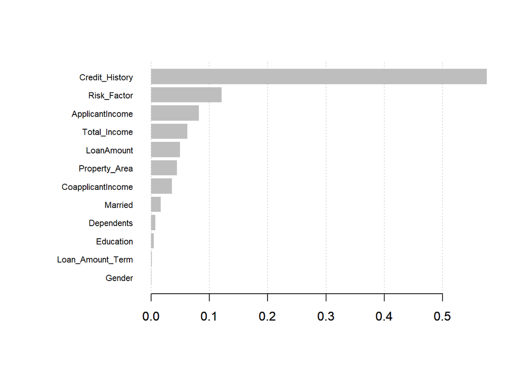

```r
# obtenemos el modelo
modelo= xgb.dump(md, with_stats=TRUE)
# obtenemos los nombres de las variables
names = dimnames(dtrain_label)[[2]]
# generamos la matriz de variables importantes
importance_matrix = xgb.importance(names, model=md)

# generamos el grafico de importancia
xgb.plot.importance(importance_matrix)
```

Es relevante la importancia de “Credit_History” y las creadas personalmente “Total_Income” y “Risk_Factor”.

**Conclusión:**

Datos del hackaton de Data Scientist:  
- Total de participantes: 4600.  
- Puesto obtenido 170.

**Opciones de mejora:**

- Explorar un mayor ajuste de XGBoost.
- Creación de nuevas variables.
- Explorar más detenídamente el factor “Property_Area” y evaluar si puede haber tres tipos de criterios diferentes en función de sus tres estados.
- Permitir que XGBoost realice la imputación.